# **04. Data Cleaning**

R101

Vít Gabrhel

# Setting up the library

- **Packages**:

```
     ggplot2        dplyr        psych summarytools       readxl    lubridate      stringr
        TRUE         TRUE         TRUE         TRUE         TRUE         TRUE         TRUE
```

# Data Exploration

## *Exploration of the raw data - [base](https://stat.ethz.ch/R-manual/R-devel/library/base/html/00Index.html) and [dplyr](https://cran.r-project.org/web/packages/dplyr/dplyr.pdf)*

- **Data** entry:

```r
bmi_1 = read_excel("bmi.xlsx", sheet = 2)
```

- Check the **class** of *bmi*:

```r
class(bmi_1)
```

```
[1] "tbl_df"     "tbl"        "data.frame"
```

- Check the **dimensions** of *bmi*:

```r
dim(bmi_1)
```

```
[1] 199   2
```

- View the **column names** of *bmi*:

```r
colnames(bmi_1)
```

```
[1] "Country"  "BMI_1980"
```

- **Structure** of the data:

```r
str(bmi_1)
```

```
Classes ‘tbl_df’, ‘tbl’ and 'data.frame':   199 obs. of  2 variables:
 $ Country : chr  "Afghanistan" "Albania" "Algeria" "Andorra" ...
 $ BMI_1980: num  20.4 25.2 23.7 25.7 20.1 ...
```

- **Glimpse**:

```r
# library(dplyr), install.packages(“dplyr“)
glimpse(bmi_1)
```

[output not shown]

- **Summary**:

```r
summary(bmi_1)
```

```
   Country             BMI_1980
 Length:199         Min.   :18.47
 Class :character   1st Qu.:21.38
 Mode  :character   Median :23.98
                    Mean   :23.55
                    3rd Qu.:25.40
                    Max.   :28.28
```

- **First** 10 rows:

```r
head(bmi_1, n = 10)
```

| Country | BMI_1980 |
| --- | --- |
| Afghanistan | 20.44348 |
| Albania | 25.17427 |
| Algeria | 23.67764 |
| Andorra | 25.67324 |
| Angola | 20.06763 |
| Antigua and Barbuda | 24.22235 |
| Argentina | 23.84436 |
| Armenia | 25.77727 |
| Australia | 23.63058 |
| Austria | 23.90340 |

| Country <chr> | BMI_1980 <dbl> |  |  |  |
| --- | --- | --- | --- | --- |
| Afghanistan | 20.44348 |  |  |  |
| Albania | 25.17427 |  |  |  |
| Algeria | 23.67764 |  |  |  |
| Andorra | 25.67324 |  |  |  |
| Angola | 20.06763 |  |  |  |
| Antigua and Barbuda | 24.22235 |  |  |  |
| Argentina | 23.84436 |  |  |  |
| Armenia | 25.77727 |  |  |  |
| Australia | 23.63058 |  |  |  |
| Austria | 23.90340 |  |  |  |

1-10 of 10 rows

- **Last** 10 rows:

```r
tail(bmi_1, n = 10)
```

| Country | BMI_1980 |
| --- | --- |
| Ukraine | 26.38022 |
| United States of America | 25.02199 |
| Uruguay | 23.25811 |
| Uzbekistan | 24.13709 |
| Vanuatu | 22.93362 |
| Venezuela (Bolivarian Republic of) | 24.67540 |
| Viet Nam | 18.59363 |
| Yemen | 23.48817 |
| Zambia | 21.37080 |
| Zimbabwe | 25.45496 |

| Country <chr> | BMI_1980 <dbl> |  |  |  |
| --- | --- | --- | --- | --- |
| Ukraine | 26.38022 |  |  |  |
| United States of America | 25.02199 |  |  |  |
| Uruguay | 23.25811 |  |  |  |
| Uzbekistan | 24.13709 |  |  |  |
| Vanuatu | 22.93362 |  |  |  |
| Venezuela (Bolivarian Republic of) | 24.67540 |  |  |  |
| Viet Nam | 18.59363 |  |  |  |
| Yemen | 23.48817 |  |  |  |
| Zambia | 21.37080 |  |  |  |
| Zimbabwe | 25.45496 |  |  |  |

1-10 of 10 rows

## *Exploration of the raw data - [psych](https://cran.r-project.org/web/packages/psych/psych.pdf)*

- Load psych:

```r
# library(psych), install.packages("psych")
```

- Check the **structure** of *bmi*, the **psych** way:

```r
describe(bmi_1)
```

|  | vars | n | mean | sd | median | trimmed | mad | min | max | range | skew | kurtosis | se |
| --- | --- | --- | --- | --- | --- | --- | --- | --- | --- | --- | --- | --- | --- |
| Country* | 1 | 199 | NaN | NA | NA | NaN | NA | Inf | -Inf | -Inf | NA | NA | NA |
| BMI_1980 | 2 | 199 | 23.55 | 2.37 | 23.98 | 23.64 | 2.8 | 18.47 | 28.28 | 9.81 | -0.34 | -0.94 | 0.17 |

|  | vars <dbl> | n <dbl> | mean <dbl> | sd <dbl> | median <dbl> | trimmed <dbl> | mad <dbl> | min <dbl> | max <dbl> |  |
| --- | --- | --- | --- | --- | --- | --- | --- | --- | --- | --- |
| Country* | 1 | 199 | NaN | NA | NA | NaN | NA | Inf | -Inf |  |
| BMI_1980 | 2 | 199 | 23.55 | 2.37 | 23.98 | 23.64 | 2.8 | 18.47 | 28.28 |  |

2 rows | 1-10 of 13 columns

- Check the **structure** of *bmi*, the **psych** way - **by group**:

```r
bmi_2 <- bmi_1 %>%
         group_by(Country) %>%
         mutate(Health = if_else(BMI_1980 <= 18.5 | BMI_1980 >= 24.9,
                                 "Unhealthy", "Normal"))
describe.by(bmi_2$BMI_1980, group = factor(bmi_2$Health))
```

```
 Descriptive statistics by group
group: Normal
```

|  | vars | n | mean | sd | median | trimmed | mad | min | max | range | skew | kurtosis | se |
| --- | --- | --- | --- | --- | --- | --- | --- | --- | --- | --- | --- | --- | --- |
| X1 | 1 | 129 | 22.28 | 1.82 | 22.65 | 22.37 | 2.21 | 18.59 | 24.78 | 6.19 | -0.3 | -1.29 | 0.16 |

|  | vars <dbl> | n <dbl> | mean <dbl> | sd <dbl> | median <dbl> | trimmed <dbl> | mad <dbl> | min <dbl> | max <dbl> |  |
| --- | --- | --- | --- | --- | --- | --- | --- | --- | --- | --- |
| X1 | 1 | 129 | 22.28 | 1.82 | 22.65 | 22.37 | 2.21 | 18.59 | 24.78 |  |

1 row | 1-10 of 13 columns

```
---------------------------------------------------------------------------------------------
group: Unhealthy
```

|  | vars | n | mean | sd | median | trimmed | mad | min | max | range | skew | kurtosis | se |
| --- | --- | --- | --- | --- | --- | --- | --- | --- | --- | --- | --- | --- | --- |
| X1 | 1 | 70 | 25.9 | 1.19 | 25.9 | 25.92 | 0.78 | 18.47 | 28.28 | 9.81 | -3.18 | 19.45 | 0.14 |

|  | vars <dbl> | n <dbl> | mean <dbl> | sd <dbl> | median <dbl> | trimmed <dbl> | mad <dbl> | min <dbl> | max <dbl> |  |
| --- | --- | --- | --- | --- | --- | --- | --- | --- | --- | --- |
| X1 | 1 | 70 | 25.9 | 1.19 | 25.9 | 25.92 | 0.78 | 18.47 | 28.28 |  |

1 row | 1-10 of 13 columns

## *Exploration of the raw data - [summarytools](https://cran.r-project.org/web/packages/summarytools/summarytools.pdf)*

- Load summarytools:

```r
# library(summarytools), install.packages("summarytools")
```

- Data:

```r
Manpower <- read.csv('Manpower.csv')
```

```r
view(dfSummary(Manpower))
```

# Introduction to Data Wrangling

- Data:

```r
Infrastructure <- read.csv2("Infrastructure.csv")
```

- Preview *Infrastructure* with **str()**:

```r
str(Infrastructure)
```

```
'data.frame':   133 obs. of  7 variables:
 $ Country         : Factor w/ 133 levels "Afghanistan",..: 126 97 26 49 40 125 56 120 43 35 ...
 $ ISO3            : Factor w/ 133 levels "AFG","ALB","ALG",..: 127 97 25 49 40 124 57 121 43 35 ...
 $ Rank            : int  1 2 3 4 5 6 7 8 9 10 ...
 $ Ports           : int  24 7 15 7 14 14 10 9 13 7 ...
 $ Roadway_Coverage: int  6586610 982000 3860800 3320410 951200 394428 1210251 352046 644480 65050 ...
 $ Railway_Coverage: int  224792 87157 86000 63974 29640 16454 27182 8699 41981 5083 ...
 $ Airports        : int  13513 1218 507 346 464 460 175 98 539 83 ...
```

- Coerce *Country* to **character**:

```r
Infrastructure$Country <- as.character(Infrastructure$Country)
```

```r
Infrastructure$Rank <- as.character(Infrastructure$Rank)
```

- Look at *Infrastructure* once more with **str()**:

```r
str(Infrastructure)
```

```
'data.frame':   133 obs. of  7 variables:
 $ Country         : chr  "United States" "Russia" "China" "India" ...
 $ ISO3            : Factor w/ 133 levels "AFG","ALB","ALG",..: 127 97 25 49 40 124 57 121 43 35 ...
 $ Rank            : chr  "1" "2" "3" "4" ...
 $ Ports           : int  24 7 15 7 14 14 10 9 13 7 ...
 $ Roadway_Coverage: int  6586610 982000 3860800 3320410 951200 394428 1210251 352046 644480 65050 ...
 $ Railway_Coverage: int  224792 87157 86000 63974 29640 16454 27182 8699 41981 5083 ...
 $ Airports        : int  13513 1218 507 346 464 460 175 98 539 83 ...
```

## *Strings*

- Load the stringr package:

```r
# library("stringr") install.packages("stringr")
```

- **Trim** all leading and trailing whitespace:

```r
name = c(" Filip ", "Nick ", " Jonathan")
str_trim(name)
```

```
[1] "Filip"    "Nick"     "Jonathan"
```

- **Pad** these strings with leading zeros:

```r
pad = c("23485W", "8823453Q", "994Z")
str_pad(pad, width = 9, side = "left", pad = "0")
```

```
[1] "00023485W" "08823453Q" "00000994Z"
```

```r
head(Manpower$Country)
```

```
[1] United States  Russia         China          India          France         United Kingdom
133 Levels: Afghanistan Albania Algeria Angola Argentina Armenia Australia Austria Azerbaijan Bahrain Bangladesh ... Zimbabwe
```

- Make states all **uppercase** and save result:

```r
# to states_upper
states_upper <- toupper(Manpower$Country)
head(states_upper)
```

```
[1] "UNITED STATES"  "RUSSIA"         "CHINA"          "INDIA"          "FRANCE"         "UNITED KINGDOM"
```

- Make states_upper all **lowercase** again:

```r
states_lower <- tolower(Manpower$Country)
head(states_lower)
```

```
[1] "united states"  "russia"         "china"          "india"          "france"         "united kingdom"
```

- Look at the **head** of *Infrastructure*:

```r
head(Infrastructure)
```

|  | Country | ISO3 | Rank | Ports | Roadway_Coverage | Railway_Coverage | Airports |
| --- | --- | --- | --- | --- | --- | --- | --- |
| 1 | United States | USA | 1 | 24 | 6586610 | 224792 | 13513 |
| 2 | Russia | RUS | 2 | 7 | 982000 | 87157 | 1218 |
| 3 | China | CHN | 3 | 15 | 3860800 | 86000 | 507 |
| 4 | India | IND | 4 | 7 | 3320410 | 63974 | 346 |
| 5 | France | FRA | 5 | 14 | 951200 | 29640 | 464 |
| 6 | United Kingdom | UKD | 6 | 14 | 394428 | 16454 | 460 |

|  | Country <chr> | ISO3 <fctr> | Rank <chr> | Ports <int> | Roadway_Coverage <int> | Railway_Coverage <int> | Airports <int> |
| --- | --- | --- | --- | --- | --- | --- | --- |
| 1 | United States | USA | 1 | 24 | 6586610 | 224792 | 13513 |
| 2 | Russia | RUS | 2 | 7 | 982000 | 87157 | 1218 |
| 3 | China | CHN | 3 | 15 | 3860800 | 86000 | 507 |
| 4 | India | IND | 4 | 7 | 3320410 | 63974 | 346 |
| 5 | France | FRA | 5 | 14 | 951200 | 29640 | 464 |
| 6 | United Kingdom | UKD | 6 | 14 | 394428 | 16454 | 460 |

6 rows

- **Detect** all “Republic” in *Country*:

```r
str_detect(Infrastructure$Country, "Republic")
```

```
  [1] FALSE FALSE FALSE FALSE FALSE FALSE FALSE FALSE FALSE FALSE FALSE FALSE FALSE FALSE FALSE FALSE FALSE FALSE FALSE FALSE
 [21] FALSE FALSE FALSE FALSE FALSE FALSE FALSE FALSE FALSE FALSE FALSE  TRUE FALSE FALSE FALSE FALSE FALSE FALSE FALSE FALSE
 [41] FALSE FALSE FALSE FALSE FALSE FALSE FALSE FALSE FALSE FALSE FALSE FALSE FALSE FALSE FALSE FALSE FALSE FALSE FALSE FALSE
 [61] FALSE FALSE FALSE FALSE FALSE FALSE FALSE FALSE FALSE FALSE FALSE FALSE FALSE FALSE FALSE  TRUE FALSE FALSE FALSE FALSE
 [81] FALSE FALSE FALSE FALSE FALSE FALSE FALSE FALSE FALSE FALSE FALSE FALSE FALSE FALSE FALSE FALSE FALSE FALSE FALSE FALSE
[101] FALSE FALSE FALSE FALSE FALSE FALSE FALSE FALSE FALSE FALSE FALSE FALSE FALSE FALSE FALSE FALSE FALSE  TRUE FALSE FALSE
[121] FALSE FALSE  TRUE FALSE FALSE FALSE FALSE FALSE  TRUE FALSE FALSE FALSE FALSE
```

- In the Country column, **replace** “Republic” with “R”…:

```r
Infrastructure$Country <- str_replace(Infrastructure$Country, "Republic", "R")
```

## *Valid Values*

- In R, represented as NA
- May appear in other forms
  - N/A (Excel)
  - Single dot (SPSS, SAS)
  - Empty string
- **Inf** - “Infinite value” (indicative of outliers?):

```r
1/0
```

```
[1] Inf
```

```r
1/0 + 1/0
```

```
[1] Inf
```

```r
33333^33333
```

```
[1] Inf
```

- **NaN** - “Not a number” (rethink a variable?):

```r
0/0
```

```
[1] NaN
```

```r
1/0 - 1/0
```

```
[1] NaN
```

- **character**:

```r
"treatment", "123", "A"
```

- **numeric**:

```r
23.44, 120, NaN, Inf
```

- **integer**:

```r
4L, 1123L
```

- **factor**:

```r
factor("Hello"), factor(8)
```

- **logical**:

```r
TRUE, FALSE, NA
```

## *Missing Values*

- **Data**:

```r
name = c("Jerry", "Beth", "Rick", "Morty")
n_friends = c(NaN, NA, Inf, 2)
status = c("Listening to human music", "Happy Family", "Garage", "")
social_df = data.frame(cbind(name, n_friends, status))
```

- Call **is.na()** on the **full** *social_df* to **spot all NAs**:

```r
is.na(social_df)
```

```
      name n_friends status
[1,] FALSE     FALSE  FALSE
[2,] FALSE      TRUE  FALSE
[3,] FALSE     FALSE  FALSE
[4,] FALSE     FALSE  FALSE
```

- Use the **any()** function to ask whether there are **any NAs** in the data:

```r
any(is.na(social_df))
```

```
[1] TRUE
```

- View a **summary()** of the dataset:

```r
summary(social_df)
```

```
    name   n_friends                      status
 Beth :1   2   :1                            :1
 Jerry:1   Inf :1    Garage                  :1
 Morty:1   NaN :1    Happy Family            :1
 Rick :1   NA's:1    Listening to human music:1
```

- Call **table()** on the *status* column:

```r
table(social_df$status)
```

```
                                           Garage             Happy Family Listening to human music
                       1                        1                        1                        1
```

- **Replace all empty strings** in *status* with **NA**:

```r
social_df$status[social_df$status == ""] <- NA
```

- **Print** *social_df* to the console:

```r
social_df
```

| name | n_friends | status |
| --- | --- | --- |
| Jerry | NaN | Listening to human music |
| Beth | NA | Happy Family |
| Rick | Inf | Garage |
| Morty | 2 | NA |

| name <fctr> | n_friends <fctr> | status <fctr> |  |  |
| --- | --- | --- | --- | --- |
| Jerry | NaN | Listening to human music |  |  |
| Beth | NA | Happy Family |  |  |
| Rick | Inf | Garage |  |  |
| Morty | 2 | NA |  |  |

4 rows

- Use **complete.cases()** to see which **rows have no missing values**:

```r
complete.cases(social_df)
```

```
[1]  TRUE FALSE  TRUE FALSE
```

- Use **na.omit()** to **remove all rows** with **any missing values**:

```r
na.omit(social_df)
```

|  | name | n_friends | status |
| --- | --- | --- | --- |
| 1 | Jerry | NaN | Listening to human music |
| 3 | Rick | Inf | Garage |

|  | name <fctr> | n_friends <fctr> | status <fctr> |  |
| --- | --- | --- | --- | --- |
| 1 | Jerry | NaN | Listening to human music |  |
| 3 | Rick | Inf | Garage |  |

2 rows

## *Outliers*

- **Data**:

```r
Infrastructure = read.csv2("Infrastructure.csv")
```

- **Histogram**:

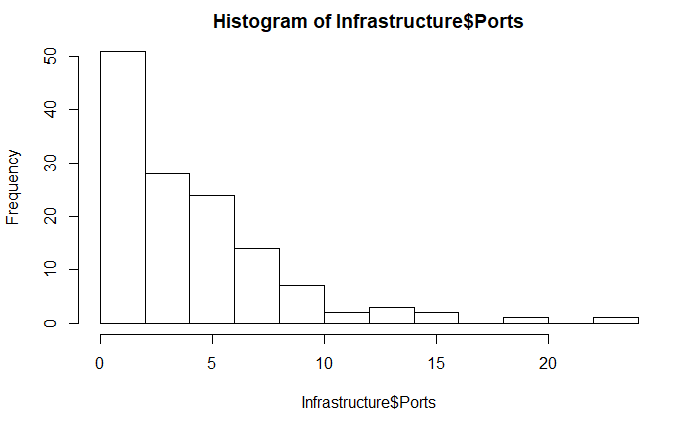

```r
hist(Infrastructure$Ports)
```

- **Boxplot**:

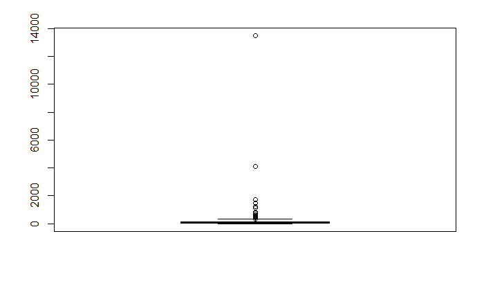

```r
boxplot(Infrastructure$Airports)
```

- **Scatterplot**:

```r
plot(Infrastructure$Railway_Coverage, Infrastructure$Roadway_Coverage)
```

[output not shown]

## Resources

[DataCamp’s Free Classroom Model Used in 180 Countries](https://www.datacamp.com/community/blog/datacamps-free-classroom-model-used-in-180-countries?fbclid=IwAR1Bo0B4-D2M7LDAGUg6LVbYKyeJn4O6FYxKs0wqEgA7u0EzM3cUOzHSGKY)

[This R Data Import Tutorial Is Everything You Need](https://www.datacamp.com/community/tutorials/r-data-import-tutorial)

[The Landscape of R Packages for Automated Exploratory Data Analysis](https://journal.r-project.org/archive/2019/RJ-2019-033/RJ-2019-033.pdf)